# Probabilidad

Francisco Marquez Aguilar

2025-09-15

# Introduccion

## ¿que es?

La probabilidad es un concepto de matemáticas que mide las posibilidades de que ocurra un resultado. Estas posibilidades se obtienen a partir de la relación (división) entre el número de casos favorables y el total de casos posibles.

# Fenomeno aleatorio

Es evidente que las regularidades de los fenómenos aleatorios solo se manifiestan mediante la observación repetida. Por lo tanto, solo se pueden estudiar aquellos fenómenos aleatorios que son observables, al menos potencialmente, indefinidamente. Dichos fenómenos aleatorios se denominan fenómenos aleatorios de masaCabe destacar que para estudiar estos fenómenos no es estrictamente necesario que sean observables muchas veces. Tras estudiar las regularidades de los fenómenos aleatorios elementales y, con base en este estudio, construir la teoría correspondiente, se pueden estudiar teóricamente fenómenos aleatorios más complejos, incluyendo aquellos que no son directamente observables, el evento aleatorio mas vacio y observable en la vida diaria es el simple lanzamiento de un par de dados, algo tan simple como complejo a la vez

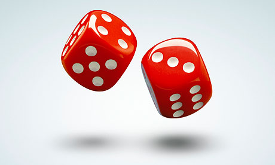

# Espacio muestral

El espacio muestral es el el grupo de todos los resultados específicos que se pueden obtener tras una experimentación de carácter aleatorio. A cada uno de sus componentes de un espacio muestral, también conocido como espacio de muestreo, se los define como puntos muestrales o, simplemente, muestras.

Es importante indicar que el concepto de espacio (palabra con origen en el latín spatium) refiere al área que consigue contener a la materia existente, la capacidad de un territorio o la porción que ocupa un objeto sensible. El término posee quince significados reconocidos por el diccionario de la Real Academia Española (RAE).

Muestral, por su parte, es lo que pertenece o guarda relación con una muestra (tal como se conoce a la parte que se extrae de un conjunto mediante algún método que permite considerarla como representativa de éste). Una muestra también es una evidencia, demostración, prueba o señal de algo.

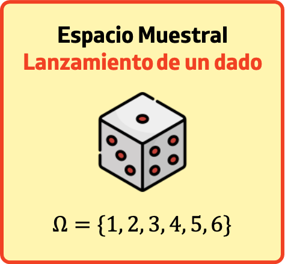

# Evento

S = {(T, T, T), (T, T, H), (T, H, T), (T, H, H), (H, T, T), (H, T, H), (H, H, T), (H, H, H)}

Supongamos que queremos encontrar sólo los resultados que tengan al menos dos caras; entonces el conjunto de todas esas posibilidades se puede dar como:

E = { (H, T, H), (H, H, T), (H, H, H), (T, H, H)}

Por tanto, un evento es un subconjunto del espacio muestral, es decir, E es un subconjunto de S.

Podría haber muchos eventos asociados a un espacio muestral dado. Para que ocurra cualquier evento, el resultado del experimento debe ser un elemento del conjunto de eventos E.

[figure not shown]

# Teoremas

Los teoremas fundamentales de probabilidad incluyen regla de adicion –regla de complementación para el evento contrario –egla del producto para la intersección de eventos -

Estos teoremas forman la base para cuantificar la incertidumbre en diversas situaciones.

## Regla de la adicion

Así pues, cuando una serie de sucesos son incompatibles entre sí, para hallar la probabilidad de que cualquiera de ellos ocurra es simplemente la suma de probabilidades de cada uno de ellos. Debe tenerse en cuenta en este caso que no hace falta referirse a la probabilidad de la unión de los sucesos como la probabilidad de que al menos uno de ellos ocurra, teniendo en cuenta que, al ser incompatibles entre sí, aquellos no pueden ocurrir a la vez.

La regla de la adición no debe utilizarse en el caso de que los sucesos incluidos en la unión sean compatibles entre sí, debiéndo utilizarse en ese caso el principio o regla de inclusión-exclusión.

## Regla de multiplicacion

La regla de la multiplicación o regla del producto, permite encontrar la probabilidad de que ocurra el evento A y el evento B al mismo tiempo (probabilidad conjunta). Esta regla depende de si los eventos son dependientes o independientes.

Eventos dependientes Dos eventos A y B son dependientes, si la ocurrencia de uno de ellos afecta la ocurrencia del otro. Para eventos dependientes, la regla de la multiplicación establece que:

regla de la multiplicación o producto de probabilidad

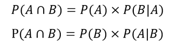

## Teorema de Bayes

El teorema de Bayes es una herramienta fundamental en estadística y probabilidades que permite actualizar la probabilidad de un evento después de considerar nueva información. Sin embargo, muchas personas encuentran difícil entenderlo por completo. En esta entrada de blog, se proporcionará una explicación del teorema de Bayes de manera sencilla y accesible para todos.

Explicación del Teorema de Bayes

El teorema de Bayes establece que la probabilidad de un evento A dado un evento B es igual a la probabilidad del evento B dado A multiplicado por la probabilidad de A dividido por la probabilidad de B. Es decir:

P(A|B) = P(B|A) * P(A) / P(B)

Donde:

P(A|B) es la probabilidad de A dado B.

P(B|A) es la probabilidad de B dado A.

P(A) es la probabilidad de A.

P(B) es la probabilidad de B.

Este teorema se puede aplicar a una amplia variedad de situaciones en las que se tienen dos eventos relacionados. Por ejemplo, se puede usar para calcular la probabilidad de tener una enfermedad dado un resultado de prueba positivo o para estimar la probabilidad de que una persona haya cometido un crimen dado ciertos datos de evidencia.

# Conclusiones

En conclusion los teoremas asi como la probabilidad son una herramients fundamnetal en la vida diaria puesto que nos ayudan a coomprender y analizar temas relacionados antiguamente con el azar como el simple tiro de un dado hasta temas de mayor complejidad y con un grado mayor de importancia, alli la importancia en nuestra vida diaria